# Variables aleatorias discreta

El siguiente gráfico corresponde a la función $F_X(t)$, la función de distribución acumulada de la variable $X$, que se mantiene constante para $t>8.5$ y para $t<5.5$

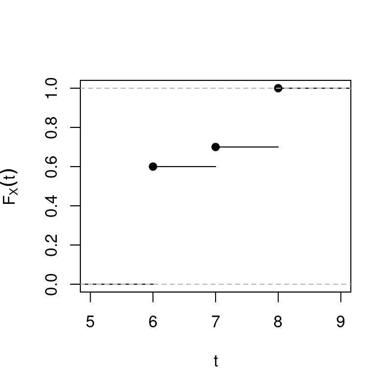

Indicar la cantidad de valores que conforman el rango de $X$: $\#Rg(X)$.

Indicar cuál es el menor valor perteneciente al rango de $X$.

Indicar cuál es el valor de $P(X\leq 7)$

Indicar cuál es el valor de $P(X=7)$

Indicar cuál es el valor de $P(X\geq 7)$

Indicar cuál es el valor de $P(6 \leq X< 8)$

Calcular $\displaystyle {\lim_{t\to -\infty }}F_X(t)$

Calcular $\displaystyle{\lim_{t\to +\infty}} F_X(t)$

Recordemos que $F_X$, la función de distribución acumulada de la variable aleatoria $X$, está definida por
$$F_X(t)=\mathbb P(X\leq t)\;, \forall t\in \mathbb
R.$$
Es una función definida para cada valore $t$ en los reales y toma valores en el conjunto $[0,1]$: $F_X: \mathbb R\to [0,1]$.

Conodiendo $F_X$, el rango de $X$ está dado por los puntos de discontinuidad de $F_X$. Los valores en el eje horizontal donde la función pega un salto. En este caso, tenemos que $Rg(X)=\{6, 8, 7\}$ y por lo tanto, $\#Rg(X)=3$ y el menor valor perteneciente al rango es el 6.

Por definición de $F_X$, $P(X\leq 7)=F_X(7)=0.7$, como vemos en el gráfico.

Además, $P(X\leq 7)=p_X(7)$, la función de probabilidad puntual, está dada por el *salto* de la función acumulada en $7$. Es decir, $p_X(7) =F_X(7)-F_X(7^-)=0.1$, como vemos en el grárico, recordando que $F_X(7^-)$ denota el límite por izquierda.

Para calcular $P(X\geq 7)$ hay diferentes estrategias. Vamos a optar por el complemento.
$$\begin{eqnarray*}
P(X\geq 7)&=& 1-P(X< 7)=1-(P(X\leq 7)-P(X= 7))\\
&=&1-\left\{F_X(7)-(F_X(7)-F_X(7^-))\right\}\\
&=& 1-F_X(7^-)=0.4.
\end{eqnarray*}$$

Acá, de nuevo, hay que acomodar para conseguir lo que uno quiere en terminos de $F_X$. Operando como hicimos en el caso anterior, llegamos a que

$$P(6 \leq X<
8)=F_X(8^-)-F_X(6^-)=0.7.$$

Por último, toda función de distribución acumulada satisface las siguientes dos propiedades:
$$\displaystyle
{\lim_{t\to -\infty }}F_X(t)=0.$$

$$\displaystyle{\lim_{t\to +\infty}}
F_X(t)=1.$$

El siguiente gráfico corresponde a la función $F_X(t)$, la función de distribución acumulada de la variable $X$, que se mantiene constante para $t>12.5$ y para $t<7.5$

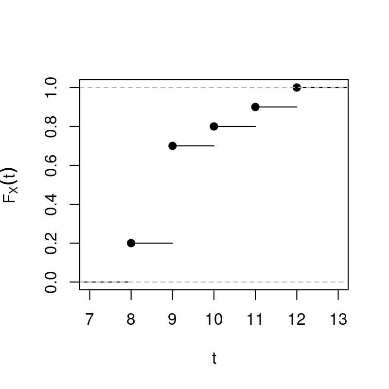

Indicar la cantidad de valores que conforman el rango de $X$: $\#Rg(X)$.

Indicar cuál es el menor valor perteneciente al rango de $X$.

Indicar cuál es el valor de $P(X\leq 9)$

Indicar cuál es el valor de $P(X=9)$

Indicar cuál es el valor de $P(X\geq 9)$

Indicar cuál es el valor de $P(8 \leq X< 10)$

Calcular $\displaystyle {\lim_{t\to -\infty }}F_X(t)$

Calcular $\displaystyle{\lim_{t\to +\infty}} F_X(t)$

Recordemos que $F_X$, la función de distribución acumulada de la variable aleatoria $X$, está definida por
$$F_X(t)=\mathbb P(X\leq t)\;, \forall t\in \mathbb
R.$$
Es una función definida para cada valore $t$ en los reales y toma valores en el conjunto $[0,1]$: $F_X: \mathbb R\to [0,1]$.

Conodiendo $F_X$, el rango de $X$ está dado por los puntos de discontinuidad de $F_X$. Los valores en el eje horizontal donde la función pega un salto. En este caso, tenemos que $Rg(X)=\{9, 10, 12, 11, 8\}$ y por lo tanto, $\#Rg(X)=5$ y el menor valor perteneciente al rango es el 8.

Por definición de $F_X$, $P(X\leq 9)=F_X(9)=0.7$, como vemos en el gráfico.

Además, $P(X\leq 9)=p_X(9)$, la función de probabilidad puntual, está dada por el *salto* de la función acumulada en $9$. Es decir, $p_X(9) =F_X(9)-F_X(9^-)=0.5$, como vemos en el grárico, recordando que $F_X(9^-)$ denota el límite por izquierda.

Para calcular $P(X\geq 9)$ hay diferentes estrategias. Vamos a optar por el complemento.
$$\begin{eqnarray*}
P(X\geq 9)&=& 1-P(X< 9)=1-(P(X\leq 9)-P(X= 9))\\
&=&1-\left\{F_X(9)-(F_X(9)-F_X(9^-))\right\}\\
&=& 1-F_X(9^-)=0.8.
\end{eqnarray*}$$

Acá, de nuevo, hay que acomodar para conseguir lo que uno quiere en terminos de $F_X$. Operando como hicimos en el caso anterior, llegamos a que

$$P(8 \leq X<
10)=F_X(10^-)-F_X(8^-)=0.7.$$

Por último, toda función de distribución acumulada satisface las siguientes dos propiedades:
$$\displaystyle
{\lim_{t\to -\infty }}F_X(t)=0.$$

$$\displaystyle{\lim_{t\to +\infty}}
F_X(t)=1.$$

El siguiente gráfico corresponde a la función $F_X(t)$, la función de distribución acumulada de la variable $X$, que se mantiene constante para $t>8.5$ y para $t<5.5$

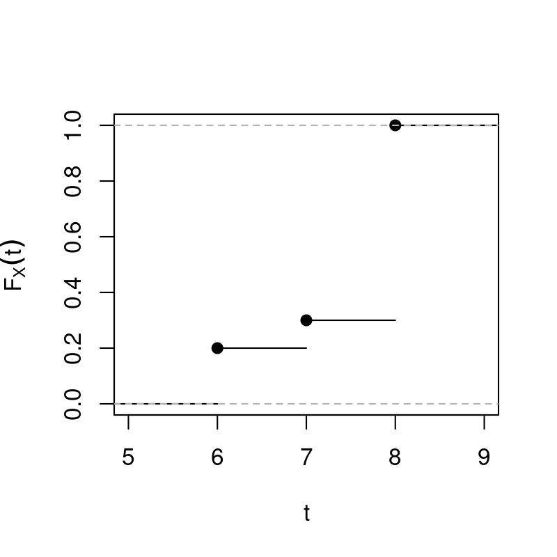

Indicar la cantidad de valores que conforman el rango de $X$: $\#Rg(X)$.

Indicar cuál es el menor valor perteneciente al rango de $X$.

Indicar cuál es el valor de $P(X\leq 7)$

Indicar cuál es el valor de $P(X=7)$

Indicar cuál es el valor de $P(X\geq 7)$

Indicar cuál es el valor de $P(6 \leq X< 8)$

Calcular $\displaystyle {\lim_{t\to -\infty }}F_X(t)$

Calcular $\displaystyle{\lim_{t\to +\infty}} F_X(t)$

Recordemos que $F_X$, la función de distribución acumulada de la variable aleatoria $X$, está definida por
$$F_X(t)=\mathbb P(X\leq t)\;, \forall t\in \mathbb
R.$$
Es una función definida para cada valore $t$ en los reales y toma valores en el conjunto $[0,1]$: $F_X: \mathbb R\to [0,1]$.

Conodiendo $F_X$, el rango de $X$ está dado por los puntos de discontinuidad de $F_X$. Los valores en el eje horizontal donde la función pega un salto. En este caso, tenemos que $Rg(X)=\{6, 8, 7\}$ y por lo tanto, $\#Rg(X)=3$ y el menor valor perteneciente al rango es el 6.

Por definición de $F_X$, $P(X\leq 7)=F_X(7)=0.3$, como vemos en el gráfico.

Además, $P(X\leq 7)=p_X(7)$, la función de probabilidad puntual, está dada por el *salto* de la función acumulada en $7$. Es decir, $p_X(7) =F_X(7)-F_X(7^-)=0.1$, como vemos en el grárico, recordando que $F_X(7^-)$ denota el límite por izquierda.

Para calcular $P(X\geq 7)$ hay diferentes estrategias. Vamos a optar por el complemento.
$$\begin{eqnarray*}
P(X\geq 7)&=& 1-P(X< 7)=1-(P(X\leq 7)-P(X= 7))\\
&=&1-\left\{F_X(7)-(F_X(7)-F_X(7^-))\right\}\\
&=& 1-F_X(7^-)=0.8.
\end{eqnarray*}$$

Acá, de nuevo, hay que acomodar para conseguir lo que uno quiere en terminos de $F_X$. Operando como hicimos en el caso anterior, llegamos a que

$$P(6 \leq X<
8)=F_X(8^-)-F_X(6^-)=0.3.$$

Por último, toda función de distribución acumulada satisface las siguientes dos propiedades:
$$\displaystyle
{\lim_{t\to -\infty }}F_X(t)=0.$$

$$\displaystyle{\lim_{t\to +\infty}}
F_X(t)=1.$$

El siguiente gráfico corresponde a la función $F_X(t)$, la función de distribución acumulada de la variable $X$, que se mantiene constante para $t>8.5$ y para $t<5.5$

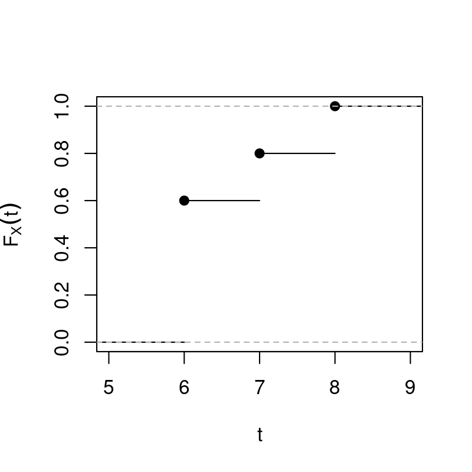

Indicar la cantidad de valores que conforman el rango de $X$: $\#Rg(X)$.

Indicar cuál es el menor valor perteneciente al rango de $X$.

Indicar cuál es el valor de $P(X\leq 7)$

Indicar cuál es el valor de $P(X=7)$

Indicar cuál es el valor de $P(X\geq 7)$

Indicar cuál es el valor de $P(6 \leq X< 8)$

Calcular $\displaystyle {\lim_{t\to -\infty }}F_X(t)$

Calcular $\displaystyle{\lim_{t\to +\infty}} F_X(t)$

Recordemos que $F_X$, la función de distribución acumulada de la variable aleatoria $X$, está definida por
$$F_X(t)=\mathbb P(X\leq t)\;, \forall t\in \mathbb
R.$$
Es una función definida para cada valore $t$ en los reales y toma valores en el conjunto $[0,1]$: $F_X: \mathbb R\to [0,1]$.

Conodiendo $F_X$, el rango de $X$ está dado por los puntos de discontinuidad de $F_X$. Los valores en el eje horizontal donde la función pega un salto. En este caso, tenemos que $Rg(X)=\{7, 6, 8\}$ y por lo tanto, $\#Rg(X)=3$ y el menor valor perteneciente al rango es el 6.

Por definición de $F_X$, $P(X\leq 7)=F_X(7)=0.8$, como vemos en el gráfico.

Además, $P(X\leq 7)=p_X(7)$, la función de probabilidad puntual, está dada por el *salto* de la función acumulada en $7$. Es decir, $p_X(7) =F_X(7)-F_X(7^-)=0.2$, como vemos en el grárico, recordando que $F_X(7^-)$ denota el límite por izquierda.

Para calcular $P(X\geq 7)$ hay diferentes estrategias. Vamos a optar por el complemento.
$$\begin{eqnarray*}
P(X\geq 7)&=& 1-P(X< 7)=1-(P(X\leq 7)-P(X= 7))\\
&=&1-\left\{F_X(7)-(F_X(7)-F_X(7^-))\right\}\\
&=& 1-F_X(7^-)=0.4.
\end{eqnarray*}$$

Acá, de nuevo, hay que acomodar para conseguir lo que uno quiere en terminos de $F_X$. Operando como hicimos en el caso anterior, llegamos a que

$$P(6 \leq X<
8)=F_X(8^-)-F_X(6^-)=0.8.$$

Por último, toda función de distribución acumulada satisface las siguientes dos propiedades:
$$\displaystyle
{\lim_{t\to -\infty }}F_X(t)=0.$$

$$\displaystyle{\lim_{t\to +\infty}}
F_X(t)=1.$$

El siguiente gráfico corresponde a la función $F_X(t)$, la función de distribución acumulada de la variable $X$, que se mantiene constante para $t>9.5$ y para $t<6.5$

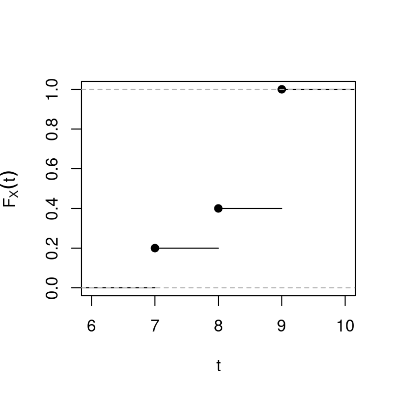

Indicar la cantidad de valores que conforman el rango de $X$: $\#Rg(X)$.

Indicar cuál es el menor valor perteneciente al rango de $X$.

Indicar cuál es el valor de $P(X\leq 8)$

Indicar cuál es el valor de $P(X=8)$

Indicar cuál es el valor de $P(X\geq 8)$

Indicar cuál es el valor de $P(7 \leq X< 9)$

Calcular $\displaystyle {\lim_{t\to -\infty }}F_X(t)$

Calcular $\displaystyle{\lim_{t\to +\infty}} F_X(t)$

Recordemos que $F_X$, la función de distribución acumulada de la variable aleatoria $X$, está definida por
$$F_X(t)=\mathbb P(X\leq t)\;, \forall t\in \mathbb
R.$$
Es una función definida para cada valore $t$ en los reales y toma valores en el conjunto $[0,1]$: $F_X: \mathbb R\to [0,1]$.

Conodiendo $F_X$, el rango de $X$ está dado por los puntos de discontinuidad de $F_X$. Los valores en el eje horizontal donde la función pega un salto. En este caso, tenemos que $Rg(X)=\{9, 7, 8\}$ y por lo tanto, $\#Rg(X)=3$ y el menor valor perteneciente al rango es el 7.

Por definición de $F_X$, $P(X\leq 8)=F_X(8)=0.4$, como vemos en el gráfico.

Además, $P(X\leq 8)=p_X(8)$, la función de probabilidad puntual, está dada por el *salto* de la función acumulada en $8$. Es decir, $p_X(8) =F_X(8)-F_X(8^-)=0.2$, como vemos en el grárico, recordando que $F_X(8^-)$ denota el límite por izquierda.

Para calcular $P(X\geq 8)$ hay diferentes estrategias. Vamos a optar por el complemento.
$$\begin{eqnarray*}
P(X\geq 8)&=& 1-P(X< 8)=1-(P(X\leq 8)-P(X= 8))\\
&=&1-\left\{F_X(8)-(F_X(8)-F_X(8^-))\right\}\\
&=& 1-F_X(8^-)=0.8.
\end{eqnarray*}$$

Acá, de nuevo, hay que acomodar para conseguir lo que uno quiere en terminos de $F_X$. Operando como hicimos en el caso anterior, llegamos a que

$$P(7 \leq X<
9)=F_X(9^-)-F_X(7^-)=0.4.$$

Por último, toda función de distribución acumulada satisface las siguientes dos propiedades:
$$\displaystyle
{\lim_{t\to -\infty }}F_X(t)=0.$$

$$\displaystyle{\lim_{t\to +\infty}}
F_X(t)=1.$$

El siguiente gráfico corresponde a la función $F_X(t)$, la función de distribución acumulada de la variable $X$, que se mantiene constante para $t>10.5$ y para $t<6.5$

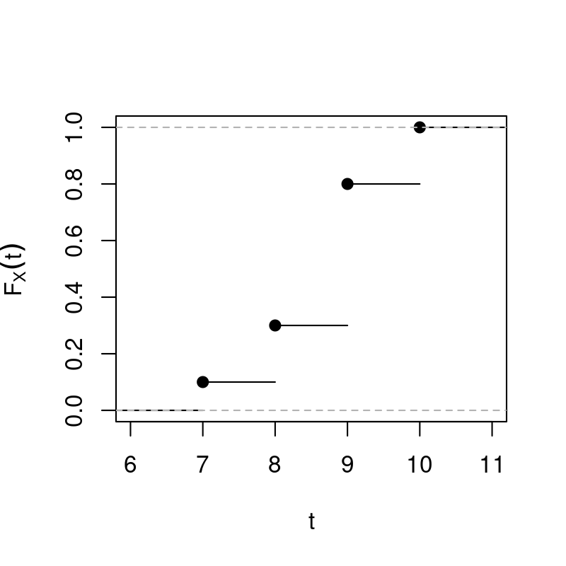

Indicar la cantidad de valores que conforman el rango de $X$: $\#Rg(X)$.

Indicar cuál es el menor valor perteneciente al rango de $X$.

Indicar cuál es el valor de $P(X\leq 8)$

Indicar cuál es el valor de $P(X=8)$

Indicar cuál es el valor de $P(X\geq 8)$

Indicar cuál es el valor de $P(7 \leq X< 9)$

Calcular $\displaystyle {\lim_{t\to -\infty }}F_X(t)$

Calcular $\displaystyle{\lim_{t\to +\infty}} F_X(t)$

Recordemos que $F_X$, la función de distribución acumulada de la variable aleatoria $X$, está definida por
$$F_X(t)=\mathbb P(X\leq t)\;, \forall t\in \mathbb
R.$$
Es una función definida para cada valore $t$ en los reales y toma valores en el conjunto $[0,1]$: $F_X: \mathbb R\to [0,1]$.

Conodiendo $F_X$, el rango de $X$ está dado por los puntos de discontinuidad de $F_X$. Los valores en el eje horizontal donde la función pega un salto. En este caso, tenemos que $Rg(X)=\{10, 9, 7, 8\}$ y por lo tanto, $\#Rg(X)=4$ y el menor valor perteneciente al rango es el 7.

Por definición de $F_X$, $P(X\leq 8)=F_X(8)=0.3$, como vemos en el gráfico.

Además, $P(X\leq 8)=p_X(8)$, la función de probabilidad puntual, está dada por el *salto* de la función acumulada en $8$. Es decir, $p_X(8) =F_X(8)-F_X(8^-)=0.2$, como vemos en el grárico, recordando que $F_X(8^-)$ denota el límite por izquierda.

Para calcular $P(X\geq 8)$ hay diferentes estrategias. Vamos a optar por el complemento.
$$\begin{eqnarray*}
P(X\geq 8)&=& 1-P(X< 8)=1-(P(X\leq 8)-P(X= 8))\\
&=&1-\left\{F_X(8)-(F_X(8)-F_X(8^-))\right\}\\
&=& 1-F_X(8^-)=0.9.
\end{eqnarray*}$$

Acá, de nuevo, hay que acomodar para conseguir lo que uno quiere en terminos de $F_X$. Operando como hicimos en el caso anterior, llegamos a que

$$P(7 \leq X<
9)=F_X(9^-)-F_X(7^-)=0.3.$$

Por último, toda función de distribución acumulada satisface las siguientes dos propiedades:
$$\displaystyle
{\lim_{t\to -\infty }}F_X(t)=0.$$

$$\displaystyle{\lim_{t\to +\infty}}
F_X(t)=1.$$

El siguiente gráfico corresponde a la función $F_X(t)$, la función de distribución acumulada de la variable $X$, que se mantiene constante para $t>7.5$ y para $t<3.5$

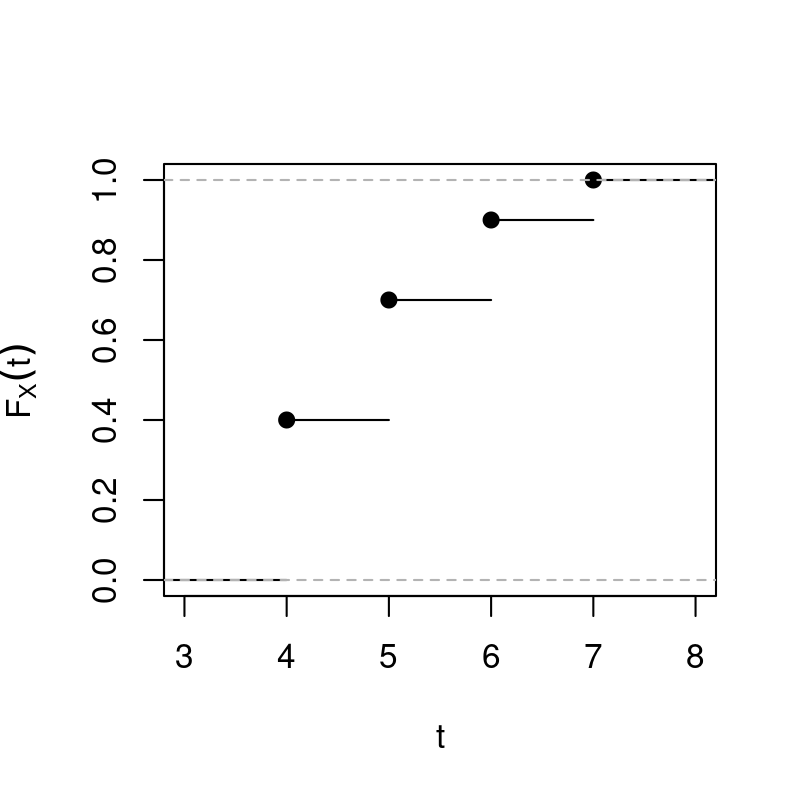

Indicar la cantidad de valores que conforman el rango de $X$: $\#Rg(X)$.

Indicar cuál es el menor valor perteneciente al rango de $X$.

Indicar cuál es el valor de $P(X\leq 5)$

Indicar cuál es el valor de $P(X=5)$

Indicar cuál es el valor de $P(X\geq 5)$

Indicar cuál es el valor de $P(4 \leq X< 6)$

Calcular $\displaystyle {\lim_{t\to -\infty }}F_X(t)$

Calcular $\displaystyle{\lim_{t\to +\infty}} F_X(t)$

Recordemos que $F_X$, la función de distribución acumulada de la variable aleatoria $X$, está definida por
$$F_X(t)=\mathbb P(X\leq t)\;, \forall t\in \mathbb
R.$$
Es una función definida para cada valore $t$ en los reales y toma valores en el conjunto $[0,1]$: $F_X: \mathbb R\to [0,1]$.

Conodiendo $F_X$, el rango de $X$ está dado por los puntos de discontinuidad de $F_X$. Los valores en el eje horizontal donde la función pega un salto. En este caso, tenemos que $Rg(X)=\{7, 5, 4, 6\}$ y por lo tanto, $\#Rg(X)=4$ y el menor valor perteneciente al rango es el 4.

Por definición de $F_X$, $P(X\leq 5)=F_X(5)=0.7$, como vemos en el gráfico.

Además, $P(X\leq 5)=p_X(5)$, la función de probabilidad puntual, está dada por el *salto* de la función acumulada en $5$. Es decir, $p_X(5) =F_X(5)-F_X(5^-)=0.3$, como vemos en el grárico, recordando que $F_X(5^-)$ denota el límite por izquierda.

Para calcular $P(X\geq 5)$ hay diferentes estrategias. Vamos a optar por el complemento.
$$\begin{eqnarray*}
P(X\geq 5)&=& 1-P(X< 5)=1-(P(X\leq 5)-P(X= 5))\\
&=&1-\left\{F_X(5)-(F_X(5)-F_X(5^-))\right\}\\
&=& 1-F_X(5^-)=0.6.
\end{eqnarray*}$$

Acá, de nuevo, hay que acomodar para conseguir lo que uno quiere en terminos de $F_X$. Operando como hicimos en el caso anterior, llegamos a que

$$P(4 \leq X<
6)=F_X(6^-)-F_X(4^-)=0.7.$$

Por último, toda función de distribución acumulada satisface las siguientes dos propiedades:
$$\displaystyle
{\lim_{t\to -\infty }}F_X(t)=0.$$

$$\displaystyle{\lim_{t\to +\infty}}
F_X(t)=1.$$

El siguiente gráfico corresponde a la función $F_X(t)$, la función de distribución acumulada de la variable $X$, que se mantiene constante para $t>10.5$ y para $t<5.5$

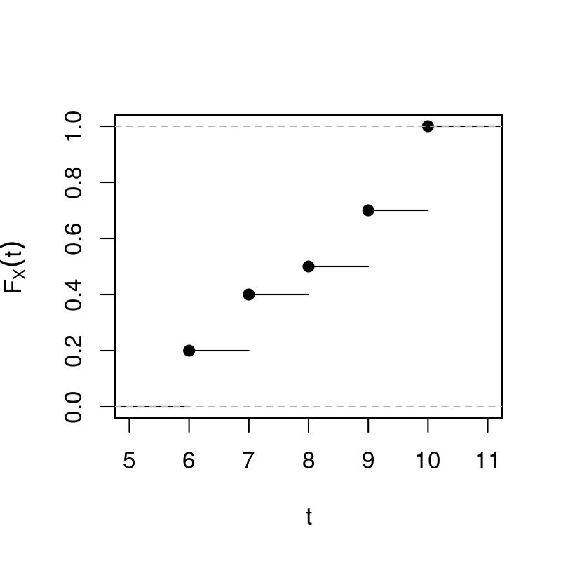

Indicar la cantidad de valores que conforman el rango de $X$: $\#Rg(X)$.

Indicar cuál es el menor valor perteneciente al rango de $X$.

Indicar cuál es el valor de $P(X\leq 7)$

Indicar cuál es el valor de $P(X=7)$

Indicar cuál es el valor de $P(X\geq 7)$

Indicar cuál es el valor de $P(6 \leq X< 8)$

Calcular $\displaystyle {\lim_{t\to -\infty }}F_X(t)$

Calcular $\displaystyle{\lim_{t\to +\infty}} F_X(t)$

Recordemos que $F_X$, la función de distribución acumulada de la variable aleatoria $X$, está definida por
$$F_X(t)=\mathbb P(X\leq t)\;, \forall t\in \mathbb
R.$$
Es una función definida para cada valore $t$ en los reales y toma valores en el conjunto $[0,1]$: $F_X: \mathbb R\to [0,1]$.

Conodiendo $F_X$, el rango de $X$ está dado por los puntos de discontinuidad de $F_X$. Los valores en el eje horizontal donde la función pega un salto. En este caso, tenemos que $Rg(X)=\{9, 7, 6, 10, 8\}$ y por lo tanto, $\#Rg(X)=5$ y el menor valor perteneciente al rango es el 6.

Por definición de $F_X$, $P(X\leq 7)=F_X(7)=0.4$, como vemos en el gráfico.

Además, $P(X\leq 7)=p_X(7)$, la función de probabilidad puntual, está dada por el *salto* de la función acumulada en $7$. Es decir, $p_X(7) =F_X(7)-F_X(7^-)=0.2$, como vemos en el grárico, recordando que $F_X(7^-)$ denota el límite por izquierda.

Para calcular $P(X\geq 7)$ hay diferentes estrategias. Vamos a optar por el complemento.
$$\begin{eqnarray*}
P(X\geq 7)&=& 1-P(X< 7)=1-(P(X\leq 7)-P(X= 7))\\
&=&1-\left\{F_X(7)-(F_X(7)-F_X(7^-))\right\}\\
&=& 1-F_X(7^-)=0.8.
\end{eqnarray*}$$

Acá, de nuevo, hay que acomodar para conseguir lo que uno quiere en terminos de $F_X$. Operando como hicimos en el caso anterior, llegamos a que

$$P(6 \leq X<
8)=F_X(8^-)-F_X(6^-)=0.4.$$

Por último, toda función de distribución acumulada satisface las siguientes dos propiedades:
$$\displaystyle
{\lim_{t\to -\infty }}F_X(t)=0.$$

$$\displaystyle{\lim_{t\to +\infty}}
F_X(t)=1.$$

El siguiente gráfico corresponde a la función $F_X(t)$, la función de distribución acumulada de la variable $X$, que se mantiene constante para $t>9.5$ y para $t<4.5$

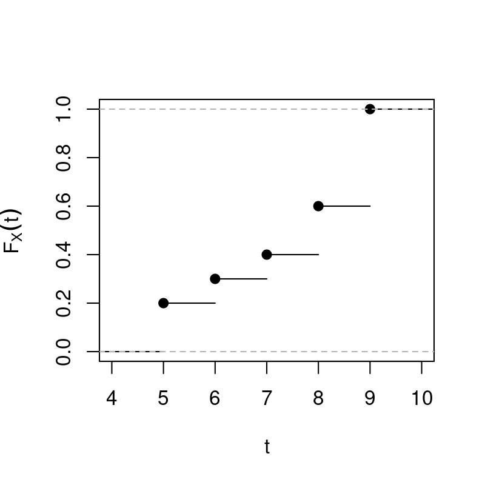

Indicar la cantidad de valores que conforman el rango de $X$: $\#Rg(X)$.

Indicar cuál es el menor valor perteneciente al rango de $X$.

Indicar cuál es el valor de $P(X\leq 6)$

Indicar cuál es el valor de $P(X=6)$

Indicar cuál es el valor de $P(X\geq 6)$

Indicar cuál es el valor de $P(5 \leq X< 7)$

Calcular $\displaystyle {\lim_{t\to -\infty }}F_X(t)$

Calcular $\displaystyle{\lim_{t\to +\infty}} F_X(t)$

Recordemos que $F_X$, la función de distribución acumulada de la variable aleatoria $X$, está definida por
$$F_X(t)=\mathbb P(X\leq t)\;, \forall t\in \mathbb
R.$$
Es una función definida para cada valore $t$ en los reales y toma valores en el conjunto $[0,1]$: $F_X: \mathbb R\to [0,1]$.

Conodiendo $F_X$, el rango de $X$ está dado por los puntos de discontinuidad de $F_X$. Los valores en el eje horizontal donde la función pega un salto. En este caso, tenemos que $Rg(X)=\{9, 8, 5, 7, 6\}$ y por lo tanto, $\#Rg(X)=5$ y el menor valor perteneciente al rango es el 5.

Por definición de $F_X$, $P(X\leq 6)=F_X(6)=0.3$, como vemos en el gráfico.

Además, $P(X\leq 6)=p_X(6)$, la función de probabilidad puntual, está dada por el *salto* de la función acumulada en $6$. Es decir, $p_X(6) =F_X(6)-F_X(6^-)=0.1$, como vemos en el grárico, recordando que $F_X(6^-)$ denota el límite por izquierda.

Para calcular $P(X\geq 6)$ hay diferentes estrategias. Vamos a optar por el complemento.
$$\begin{eqnarray*}
P(X\geq 6)&=& 1-P(X< 6)=1-(P(X\leq 6)-P(X= 6))\\
&=&1-\left\{F_X(6)-(F_X(6)-F_X(6^-))\right\}\\
&=& 1-F_X(6^-)=0.8.
\end{eqnarray*}$$

Acá, de nuevo, hay que acomodar para conseguir lo que uno quiere en terminos de $F_X$. Operando como hicimos en el caso anterior, llegamos a que

$$P(5 \leq X<
7)=F_X(7^-)-F_X(5^-)=0.3.$$

Por último, toda función de distribución acumulada satisface las siguientes dos propiedades:
$$\displaystyle
{\lim_{t\to -\infty }}F_X(t)=0.$$

$$\displaystyle{\lim_{t\to +\infty}}
F_X(t)=1.$$

El siguiente gráfico corresponde a la función $F_X(t)$, la función de distribución acumulada de la variable $X$, que se mantiene constante para $t>10.5$ y para $t<7.5$

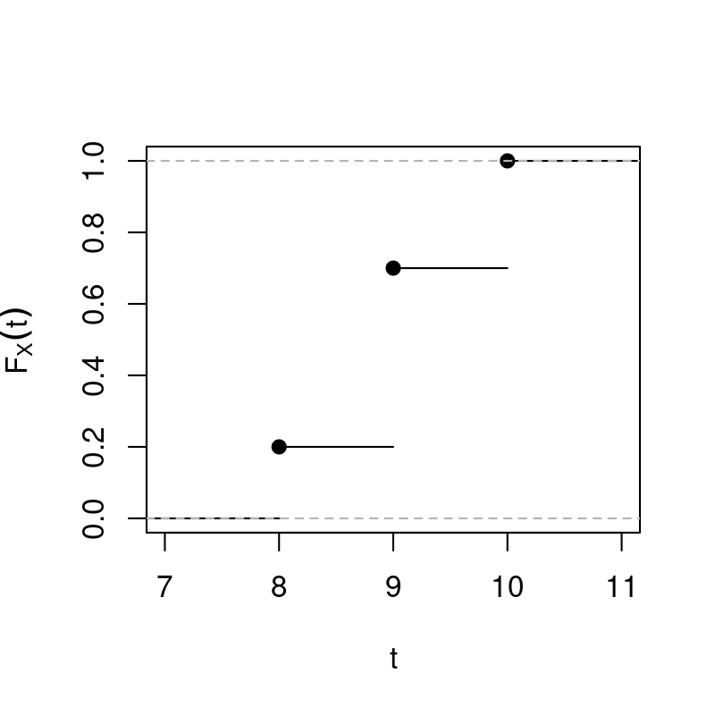

Indicar la cantidad de valores que conforman el rango de $X$: $\#Rg(X)$.

Indicar cuál es el menor valor perteneciente al rango de $X$.

Indicar cuál es el valor de $P(X\leq 9)$

Indicar cuál es el valor de $P(X=9)$

Indicar cuál es el valor de $P(X\geq 9)$

Indicar cuál es el valor de $P(8 \leq X< 10)$

Calcular $\displaystyle {\lim_{t\to -\infty }}F_X(t)$

Calcular $\displaystyle{\lim_{t\to +\infty}} F_X(t)$

Recordemos que $F_X$, la función de distribución acumulada de la variable aleatoria $X$, está definida por
$$F_X(t)=\mathbb P(X\leq t)\;, \forall t\in \mathbb
R.$$
Es una función definida para cada valore $t$ en los reales y toma valores en el conjunto $[0,1]$: $F_X: \mathbb R\to [0,1]$.

Conodiendo $F_X$, el rango de $X$ está dado por los puntos de discontinuidad de $F_X$. Los valores en el eje horizontal donde la función pega un salto. En este caso, tenemos que $Rg(X)=\{9, 10, 8\}$ y por lo tanto, $\#Rg(X)=3$ y el menor valor perteneciente al rango es el 8.

Por definición de $F_X$, $P(X\leq 9)=F_X(9)=0.7$, como vemos en el gráfico.

Además, $P(X\leq 9)=p_X(9)$, la función de probabilidad puntual, está dada por el *salto* de la función acumulada en $9$. Es decir, $p_X(9) =F_X(9)-F_X(9^-)=0.5$, como vemos en el grárico, recordando que $F_X(9^-)$ denota el límite por izquierda.

Para calcular $P(X\geq 9)$ hay diferentes estrategias. Vamos a optar por el complemento.
$$\begin{eqnarray*}
P(X\geq 9)&=& 1-P(X< 9)=1-(P(X\leq 9)-P(X= 9))\\
&=&1-\left\{F_X(9)-(F_X(9)-F_X(9^-))\right\}\\
&=& 1-F_X(9^-)=0.8.
\end{eqnarray*}$$

Acá, de nuevo, hay que acomodar para conseguir lo que uno quiere en terminos de $F_X$. Operando como hicimos en el caso anterior, llegamos a que

$$P(8 \leq X<
10)=F_X(10^-)-F_X(8^-)=0.7.$$

Por último, toda función de distribución acumulada satisface las siguientes dos propiedades:
$$\displaystyle
{\lim_{t\to -\infty }}F_X(t)=0.$$

$$\displaystyle{\lim_{t\to +\infty}}
F_X(t)=1.$$